# 12 - Datos secuenciales y modelos markovianos de estados ocultos

Cuando los datos están ordenadas en sucesiones (temporales o espaciales, por ejemplo), usualmente encontramos estructuras de dependencia dadas por la proximidad. Por ejemplo, en series de tiempo observaciones de un tiempo dado están correlacionadas con observaciones en tiempos cercanos.

Una estrategia para modelar este tipo de datos es considerar modelos que explícitamente tratan con esta dependencia temporal entre las observaciones (por ejemplo, modelos ARMA). El enfoque que consideramos aquí es uno distinto que se basa en variables latentes.

En el caso de series de tiempo, estos modelos de variables latentes se llaman **modelos de espacio de estado**, cuyos dos ejemplos más populares son:

1. *Modelos markovianos de estados escondidos* (Hidden Markov Models): cuando las variables latentes son discretas. Las observadas pueden ser numéricas o discretas.
2. *Modelos dinámicos lineales*: cuando las variables latentes son gaussianas. Las observadas generalmente son numéricas.

**Ejemplo: serie de terremotos.** La siguiente serie cuenta el número de temblores de magnitud 7 o más en el mundo, desde 1900 a 2006 ([Hidden Markov Models for Time Series](http://www.crcpress.com/product/isbn/9781584885733), de Zucchini y MacDonald):

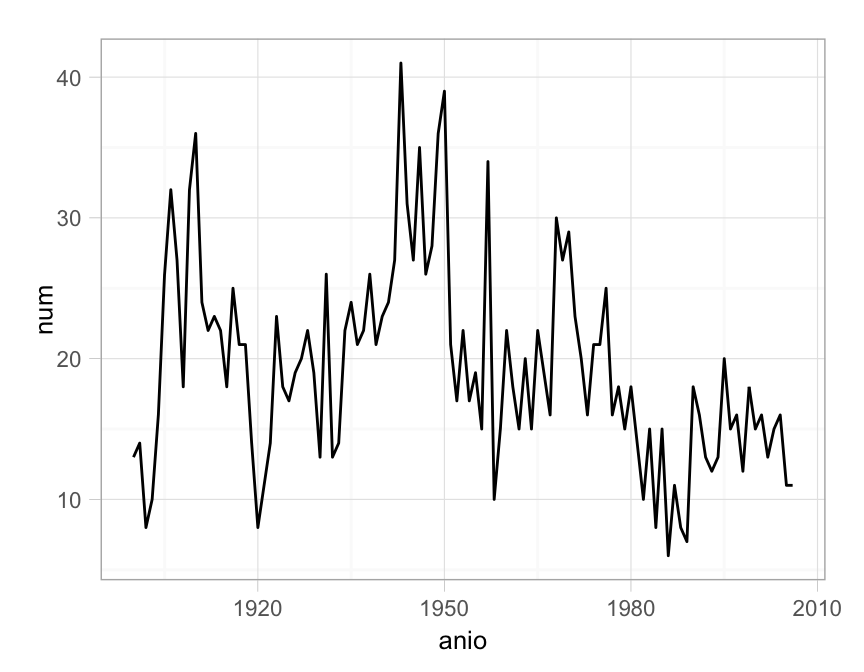

```r
terremotos <- data.frame(num = c(13,14,8,10,16,26,32,27,18,32,36,24,22,23,22,18,
  25,21,21,14,8,11,14,23,18,17,19,20,22,19,13,26,13,14,22,24,21,22,26,21,23,24,
  27,41,31,27,35,26,28,36,39,21,17,22,17,19,15,34,10,15,22,18,15,20,15,22,19,16,
  30,27,29,23,20,16,21,21,25,16,18,15,18,14,10,15,8,15,6,11,8,7,18,16,13,12,13,
  20,15,16,12,18,15,16,13,15,16,11,11), anio = 1900:2006)
ggplot(terremotos, aes(anio, num)) + geom_line()
```

Es natural intentar modelar estos conteos con una distribución Poisson. Sin embargo, un modelo Poisson para observaciones independientes no ajusta a los datos:

```r
library(ggplot2)
library(plyr)
library(dplyr)
library(nullabor)

set.seed(12875498)
lambda_1 <- mean(terremotos$num)
# pruebas de hipótesis visuales
terremotos_null <- lineup(null_dist('num', dist = 'poisson',
  params = list(lambda = lambda_1)),
  n = 20, terremotos)
```

```
## decrypt("n20q ilOl TJ IH4TOTHJ 5m")
```

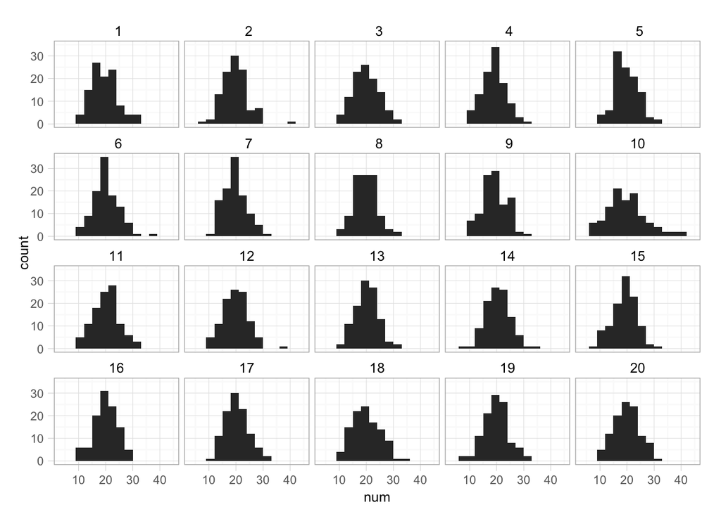

```r
ggplot(terremotos_null, aes(x = num)) +
  geom_histogram(binwidth = 3) +
  facet_wrap(~.sample)
```

Vemos que los datos presentan *sobredispersión* en relación a la distribución del modelo. Para lidiar con esta sobredispersión, podemos usar un modelo de clases latentes.

Consideramos un modelo $C\to X$, donde $C$ es la clase latente y $X$ es la observación. La observación la suponemos Poison con una media dependiendo de la clase. Ajustamos por EM y seleccionamos un modelo:

```r
library(flexmix)
model_1 <- FLXMRglm(family = "poisson")
# usa algoritmo EM para ajustar (5 repeticiones con distintos arranques):
# número de clases latentes: de 1 a 6.
modelos_fit <- initFlexmix(num ~ 1, data = terremotos, k = 1:6, model = model_1,
  nrep = 5)
```

```
## 1 : * * * * *
## 2 : * * * * *
## 3 : * * * * *
## 4 : * * * * *
## 5 : * * * * *
## 6 : * * * * *
## * * * * * *
```

```r
modelos_fit
```

```
##
## Call:
## initFlexmix(num ~ 1, data = terremotos, model = model_1,
##     k = 1:6, nrep = 5)
##
##   iter converged k k0 logLik AIC BIC ICL
## 1    2      TRUE 1  1   -392 786 789 789
## 2   34      TRUE 2  2   -360 727 735 767
## 3   43      TRUE 3  3   -357 724 737 794
## 4   37      TRUE 4  4   -357 728 746 878
## 5   33      TRUE 5  5   -357 732 756 930
## 6   32      TRUE 6  6   -357 736 765 973
```

Así que podríamos escoger, por ejemplo, el modelo de tres clases:

```r
mod_1 <- getModel(modelos_fit, which='3')
mod_1
```

```
##
## Call:
## initFlexmix(num ~ 1, data = terremotos, model = model_1,
##     k = 3, nrep = 5)
##
## Cluster sizes:
##  1  2  3
## 26 11 70
##
## convergence after 43 iterations
```

```r
probs_clase <- mod_1@prior
medias_pois <- mod_1@components
probs_clase
```

```
## [1] 0.30 0.13 0.58
```

```r
medias_pois
```

```
## $Comp.1
## $Comp.1[[1]]
## $coef
## (Intercept)
##         2.6
##
##
##
## $Comp.2
## $Comp.2[[1]]
## $coef
## (Intercept)
##         3.5
##
##
##
## $Comp.3
## $Comp.3[[1]]
## $coef
## (Intercept)
##           3
```

Para entender cómo quedó el ajuste, podemos graficar la serie original junto con la media poisson condicional de cada clase, por ejemplo:

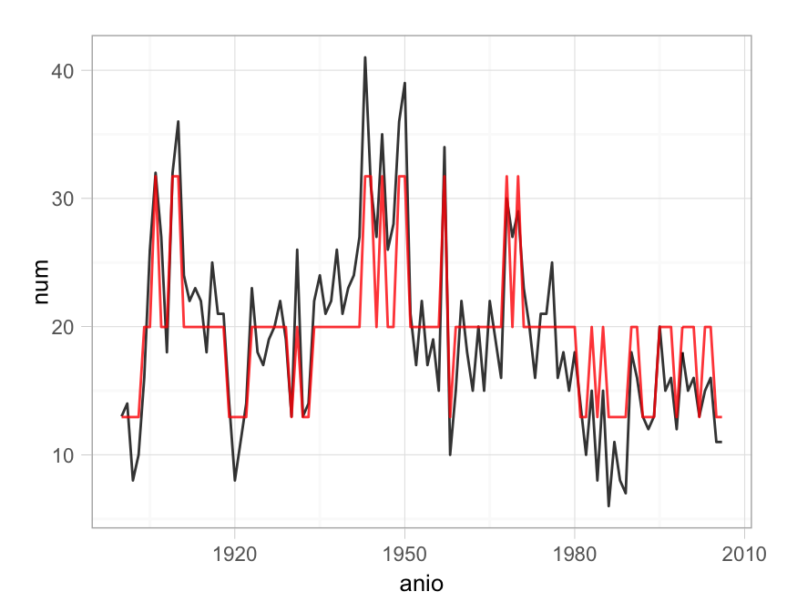

```r
terremotos$clase_1 <- clusters(mod_1)

terremotos$medias_est <- sapply(terremotos$clase_1, function(cl){
  exp(mod_1@components[[cl]][[1]]@parameters$coef[1])
})

ggplot(terremotos, aes(anio, num)) +
  geom_line(alpha = 0.8) +
  geom_line(aes(anio, medias_est), color = "red", alpha= 0.8)
```

Simulamos de estos datos y vemos que ya no hay sobredispersión (es decir, este modelo ajusta mejor que el de una sola clase):

```r
terremotos_null <- lineup(null_dist('num', dist = 'poisson',
  params = list(lambda = terremotos$medias_est)),
  n = 20, terremotos)
```

```
## decrypt("n20q ilOl TJ IH4TOTHJ 1")
```

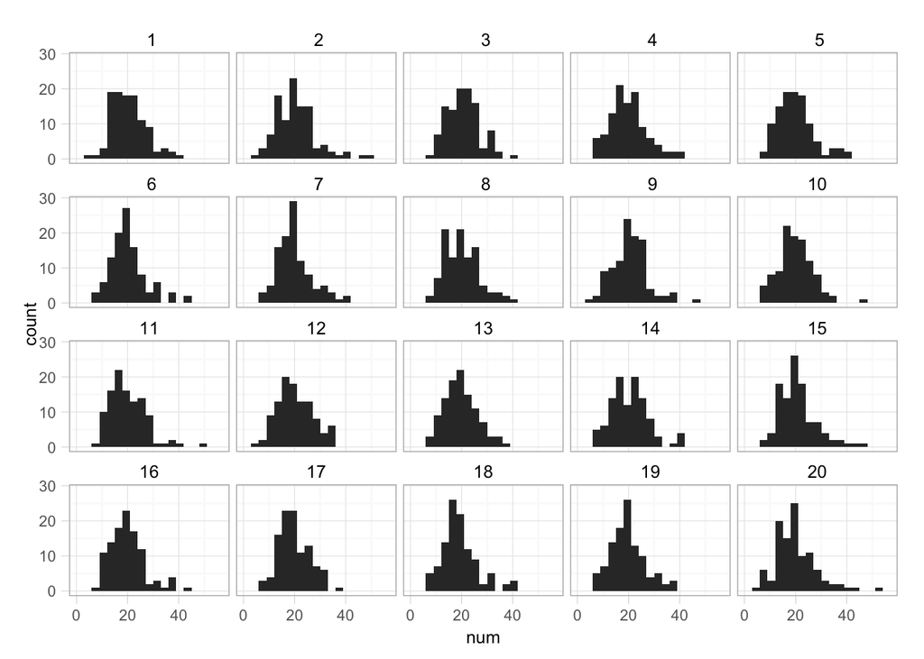

```r
ggplot(terremotos_null, aes(x = num)) +
  geom_histogram(binwidth = 3) +
  facet_wrap(~.sample)
```

Si una variable $Y$ es Poisson, su media es igual a su varianza. Ahora supón que $Y$ es una mezcla discreta Poisson: si la clase latente la denotamos por $S$ y la observación por $Y$, entonces $Y|S=s$ es Poisson con media $\lambda_s$, para $s=1\ldots,M$. Muestra que en general la varianza de $Y$ es más grande que su media (está sobredispersa). Explica en palabras de dónde viene esa sobredispersión.

### Dependencia temporal

Existe un aspecto adicional que no hemos considerado: dependencia de observaciones contiguas en las serie. Podríamos gráficar para la serie de terremotos las pares $(X_t, X_{t+1})$:

```
## geom_smooth: method="auto" and size of largest group is <1000, so using loess. Use 'method = x' to change the smoothing method.
```

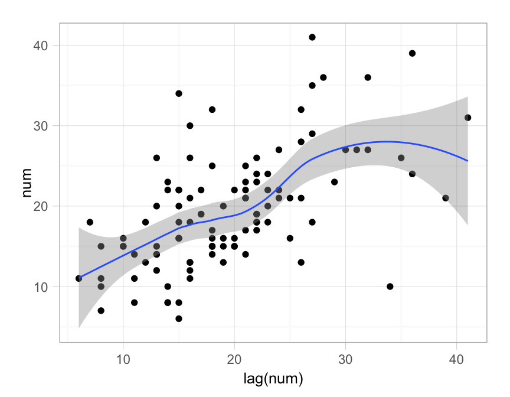

```r
ggplot(terremotos, aes(lag(num), num)) +
  geom_point() +
  geom_smooth()
```

Esta gráfica explica por qué si hacemos simulaciones de nuestro modelo ajustado (tomando en cuenta el orden temporal), estas simulaciones son claramente diferentes que los datos observados:

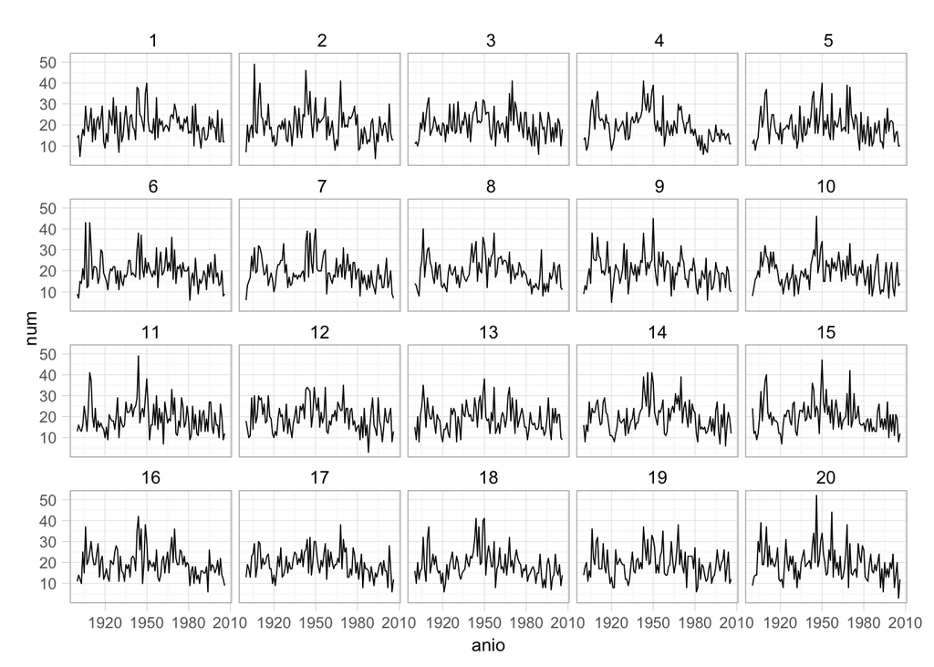

```r
ggplot(terremotos_null, aes(anio, num)) +
  geom_line(size=0.3) +
  facet_wrap(~.sample)
```

Si nos interesa hacer predicciones, el modelo de mezcla no es un buen camino, pues no utiliza adecuadamente la información más reciente para hacer los pronósticos.

Otra manera de verificar que las observaciones tienen mayor grado de correlación temporal que los simulados del modelo de mezcla es a través de los siguientes cálculos.

```r
terremotos_null %>%
  group_by(.sample) %>%
  mutate(num_lag = lag(num)) %>%
  filter(!is.na(num_lag)) %>%
  summarise(cor = cor(num, num_lag)) %>%
  arrange(desc(cor))
```

```
## Source: local data frame [20 x 2]
##
##    .sample   cor
## 1        4 0.576
## 2        8 0.407
## 3       14 0.378
## 4       18 0.312
## 5        7 0.312
## 6       10 0.304
## 7       15 0.251
## 8       12 0.246
## 9       16 0.237
## 10       9 0.227
## 11      19 0.221
## 12       2 0.211
## 13      13 0.204
## 14      11 0.175
## 15       5 0.146
## 16      17 0.117
## 17      20 0.099
## 18       1 0.084
## 19       3 0.078
## 20       6 0.032
```

Y notamos que justamente los datos con mayor correlación corresponden a los datos observados (.sample = `decrypt("n20q ilOl TJ IH4TOTHJ 1")`).

Ahora evaluamos la tasa de error de predicción a un paso de este modelo usando *validación cruzada para datos temporales*. En este caso, la predicción es simplemente la media Poisson de la clase más popular:

```r
preds_1  <- sapply(50:106 ,function(i){
  mod_1 <- flexmix(num~1, data = terremotos[1:i, , drop = FALSE], k = 3,
    model = model_1)
  mod_1
  clase_1 <- which.max(table(mod_1@cluster))
  mod_1@components[[clase_1]][[1]]@parameters[[1]]
})
```

Error medio absoluto:

```r
mean(abs(exp(preds_1) - terremotos[51:107, "num"]))
```

```
## [1] 5.7
```

#### Autocorrelación muestral

Una manera popular de diagnosticar observaciones temporalmente correlacionadas es usando la función de autocorrelación muestral. Usualmente la correlación la calculamos para pares de observaciones $(X_i,Y_i)$. En el caso de la autocorrelación, calculamos la correlación entre una serie y versiones rezagadas de la misma variable, es decir, consideramos los pares $(X_i,X_{i-k})$ para distintos valores de $k=1,2,\ldots$. La autcorrelación muestral se define:

$r_k=\frac{\sum_{t=k+1}^{T}(x_t-\overline{x})(x_{t-k}-\overline{x})}{\sum_{t=1}^T(x_t-\overline{x})},$

podemos graficar la serie $r_k$ para descubrir estructura en la serie que estamos analizando. En nuestro ejemplo:

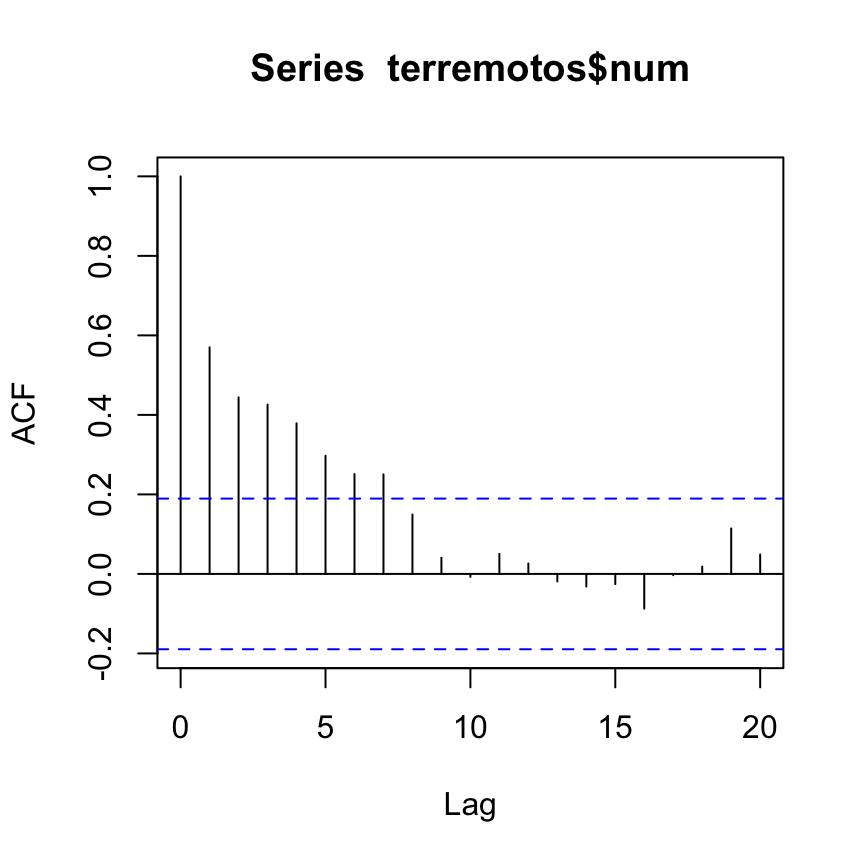

```r
acf(terremotos$num)
```

¿Cómo se ve esta gráfica cuando tenemos observaciones independientes? Esperamos observar coeficientes de correlación relativamente chicos:

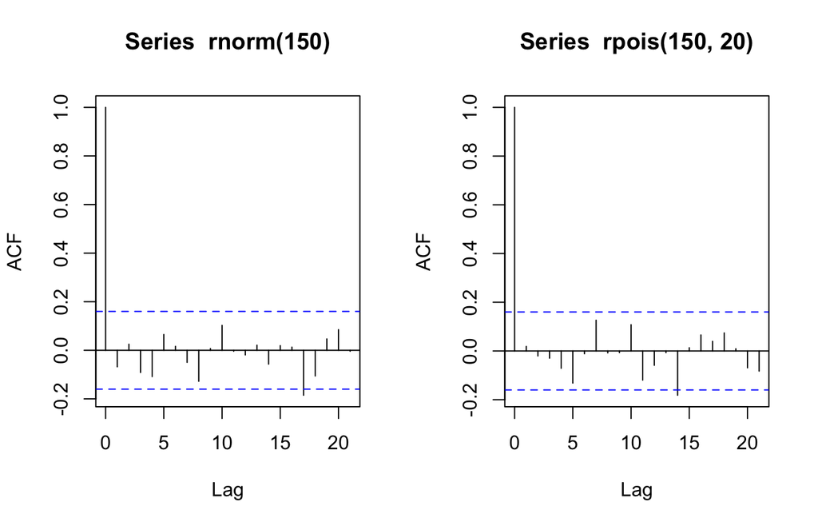

```r
set.seed(280572)
par(mfrow=c(1,2))
acf(rnorm(150))
acf(rpois(150, 20))
```

### Modelando la dependencia temporal

Si queremos capturar la estrucutra temporal de los datos, o hacer predicciones para datos futuros, es necesario modelar la estructura temporal explícita o implícitamente. Por ejemplo,podríamos intentar construir el modelo:

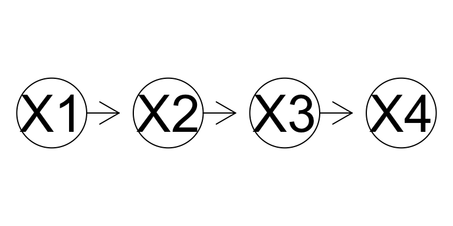

O de manera más general, tomando en cuanto dependencias más largas:

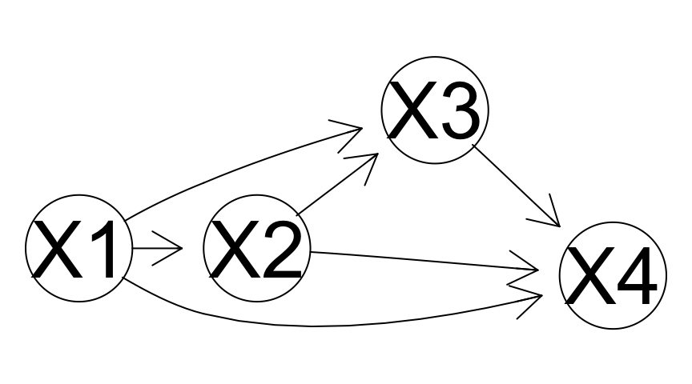

Sin embargo, utilizaremos un enfoque de variables latentes. La idea es introducir un estado latente, a partir del cual generamos las observaciones. Por ejemplo:

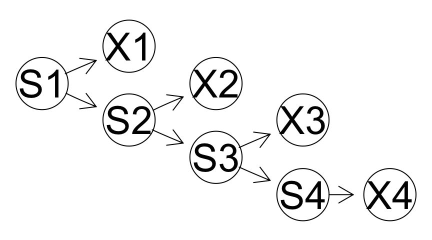

En un modelo como este, pueden existir dependencias más largas entre las $X_t$, aún cuando la estructura es relativamente simple.

¿cuáles son las independencias condicionales mostradas en la gráfica? ¿Las $X_i$ son independientes entre ellas?}

## Modelos markovianos de estados ocultos

Comenzamos con un modelo simple, que consiste de dos variables, una observada y una latente:

- $X_t$ cantidad de lluvia en mm.
- $S_t$ variable discreta con dos valores posibles: soleado o nublado.

El modelo está definido en dos grandes partes

1. Modelo de observaciones: $P(X_t|S_t).$ Este modelo está dado con dos densidades: una para la cantidad de lluvia cuando $S_t=nublado$ y otra para $S_t=soleado$.
2. Modelo de transición de estados: $P(S_{t+1}|S_t).$ Estos modelos están dados por una matriz de transición, pues supondremos que estas probabildades no cambian con $t$ (supuesto de homogeneidad). Por ejemplo, podríamos tener:

```r
p_trans <- matrix(c(0.8, 0.2, 0.3, 0.7), byrow = T, ncol = 2)
p_trans
```

```
##      [,1] [,2]
## [1,]  0.8  0.2
## [2,]  0.3  0.7
```

Y el modelo completo se puede representar como la última gráfica de la sección anterior.

```r
set.seed(2805)
estadosLluvia <- function(n){
  estado <- character(n)
  estado[1] <- sample(c('soleado', 'nublado'), 1)
  transicion <- matrix(c(0.8, 0.2, 0.2, 0.8), 2, byrow = T)
  rownames(transicion) <- c('soleado', 'nublado')
  colnames(transicion) <- c('soleado', 'nublado')
  for(j in 2:n){
    estado[j] <- sample(c('soleado', 'nublado'), 1,
      prob = transicion[estado[j - 1], ])
  }
  estado
}
estadosLluvia(10)
```

```
##  [1] "soleado" "soleado" "soleado" "soleado" "soleado" "soleado" "soleado"
##  [8] "nublado" "nublado" "nublado"
```

```r
prob_obs <- data.frame(edo = c("soleado", "nublado"), medias = c(20, 100),
  desv = c(10, 50))

obsPrecip <- function(long_serie){
  data.frame(dia = 1:long_serie, edo = estadosLluvia(long_serie)) %>%
  left_join(prob_obs) %>%
  group_by(dia) %>%
  mutate(precipit = max(rnorm(1, medias, desv), 0))
}

ej_1 <- obsPrecip(10)
```

Series simuladas de este modelo se ven como sigue:

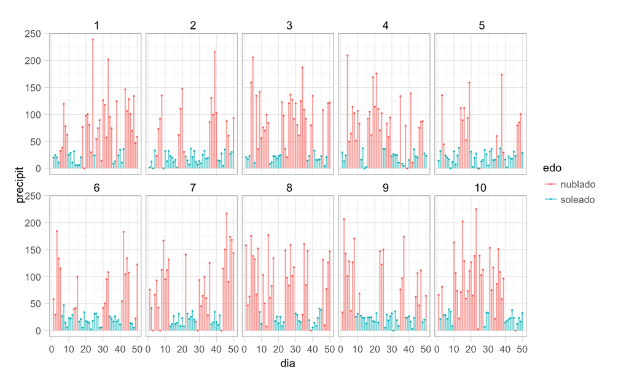

```r
sims_1 <- rdply(10, obsPrecip(50))

ggplot(sims_1, aes(x = dia, ymax = precipit, ymin = 0, y = precipit, color = edo)) +
  geom_linerange(alpha = 0.6) +
  geom_point(size=0.8) +
  facet_wrap(~.n, nrow = 2)
```

Nótese que hay dependencia secuencial en estos datos. Si sólo tuviéramos los datos observados, podríamos construir un modelo más complejo intentando entender las correlaciones secuenciales:

```r
ej_1 <- obsPrecip(1000)
```

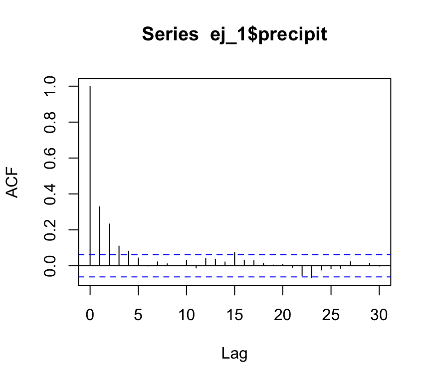

```r
acf(ej_1$precipit)
```

Ajusta con EM un modelo a estos datos usando el paquete *depmixS4*. Prueba con distintos tamaños de muestra. Por ejemplo:

```r
library(depmixS4)
datos <- sims_1
# ntimes: son 10 series de longitud 50 cada una:
mod_hmm <- depmix(precipit~1, data=datos, nstates=2,
                  family=gaussian(), ntimes=rep(50,10))
fit_1 <- fit(mod_hmm,  emcontrol=em.control(maxit=200))
```

```
## iteration 0 logLik: -2683
## iteration 5 logLik: -2539
## iteration 10 logLik: -2441
## iteration 15 logLik: -2441
## converged at iteration 19 with logLik: -2441
```

```r
summary(fit_1)
```

```
## Initial state probabilties model
##  pr1  pr2
## 0.56 0.44
##
##
## Transition matrix
##        toS1 toS2
## fromS1 0.79 0.21
## fromS2 0.23 0.77
##
## Response parameters
## Resp 1 : gaussian
##     Re1.(Intercept) Re1.sd
## St1              20     10
## St2             101     46
```

Observa que como tenemos varias series, podemos estimar las probabilidades iniciales. Cuando tenemos una sola serie, típicamente suponemos que la serie comienza en un estado, por ejemplo el primero.

Consideramos datos secuenciales $X_1,\ldots,X_T$. Un modelo markoviano de estado oculto se factoriza como (es decir, cumple las relaciones de independencia condicional indicadas en la gráfica):

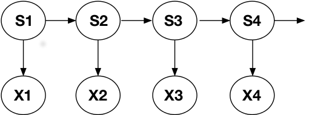

- Las variables $S_t$ (estado oculto) son latentes.
- Las variables $X_t$ no son independientes, pero son condicionalmente independientes dados los estados ocultos.
- El modelo está dado por una factorización que solo incluye términos de la forma $P(S_t|S_{t-1})$, $P(X_t|S_t)$ y $P(S_1)$.
- En los modelos de transición de estados suponemos *homogeneidad* de la cadena de Markov subyacente, es decir,$P(S_t=j|S_{t-1}=i)=p_{ij}$no depende de $t$.
- En los modelos de respuesta o de observación, las variables observadas $X_t$ pueden ser discretas o continuas. Si $X_t$ son discretas, cada $P(X_t|S_t)$ está dada por una tabla, que también suponemos *homogénea* (no depende de $t$). Si $X_t$ son continuas, entonces estas probabilidades están dadas por densidades condicionales.

**Observación**: una generalización usual de homogeneidad es incluir covariables en los modelos de respuesta o de observación, de forma que especificamos $P(X_t|S_t,Z_t )$ con modelos de regresión, por ejemplo. El análisis es condicional a los valores de $Z_t$ (no modelamos su dinámica, por ejemplo). También las probabilidades de transición pueden depender de covariables.}

**Ejemplo: serie de terremotos.** Ahora podemos regresar al ejemplo de los terremotos. Ajustamos los modelos de estado oculto a la serie (de 1 a 4 estados):

```r
library(depmixS4)
terremotos <- data.frame(num = c(13,14,8,10,16,26,32,27,18,32,36,24,22,23,22,18,
  25,21,21,14,8,11,14,23,18,17,19,20,22,19,13,26,13,14,22,24,21,22,26,21,23,24,
  27,41,31,27,35,26,28,36,39,21,17,22,17,19,15,34,10,15,22,18,15,20,15,22,19,16,
  30,27,29,23,20,16,21,21,25,16,18,15,18,14,10,15,8,15,6,11,8,7,18,16,13,12,13,
  20,15,16,12,18,15,16,13,15,16,11,11), anio = 1900:2006)
head(terremotos)
```

```
##   num anio
## 1  13 1900
## 2  14 1901
## 3   8 1902
## 4  10 1903
## 5  16 1904
## 6  26 1905
```

```r
modelos_hmm <- lapply(1:4, function(i){
  mod_hmm <- depmix(num~1, data = terremotos, nstates = i, family = poisson(),
    ntimes = 107)
  fit_hmm <- fit(mod_hmm, emcontrol = em.control(maxit = 200))
  fit_hmm
  })
```

[output not shown]

```r
sapply(modelos_hmm, BIC)
```

```
## [1] 789 707 708 744
```

```r
sapply(modelos_hmm, AIC)
```

```
## [1] 786 694 679 693
```

Podemos seleccionar el modelo con 3 estados.

```r
mod_1 <- modelos_hmm[[3]]
summary(mod_1)
```

```
## Initial state probabilties model
## pr1 pr2 pr3
##   0   1   0
##
##
## Transition matrix
##         toS1    toS2  toS3
## fromS1 0.906 4.0e-02 0.053
## fromS2 0.032 9.4e-01 0.029
## fromS3 0.190 1.1e-11 0.810
##
## Response parameters
## Resp 1 : poisson
##     Re1.(Intercept)
## St1             3.0
## St2             2.6
## St3             3.4
```

Simulaciones de este modelo dan los siguiente resultados, en donde es difícil distinguir los datos observados:

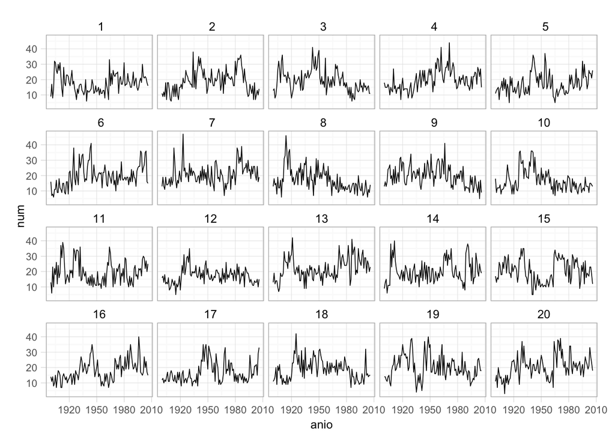

```r
class(mod_1) <- 'depmix'
set.seed(2805)
sims_1 <- simulate(mod_1, nsim = 19)
terremotos_null <- data.frame(num = sims_1@response[[1]][[1]]@y,
  anio = rep(terremotos$anio, 19)) %>%
  rbind(terremotos)
codigo <- sample(1:20)
terremotos_null$tipo <- rep(codigo, each = 107)

ggplot(terremotos_null, aes(x = anio, y = num)) +
  geom_line(size=0.3) +
  facet_wrap(~tipo)
```

```r
# verdaderas están en: codigo[20]
```

Vemos que las autocorrelaciones de grado 1 son similares:

```r
terremotos_null %>%
  group_by(tipo) %>%
  mutate(num_lag = lag(num)) %>%
  filter(!is.na(num_lag)) %>%
  summarise(cor = cor(num, num_lag))
```

```
## Source: local data frame [20 x 2]
##
##    tipo  cor
## 1     1 0.38
## 2     2 0.56
## 3     3 0.58
## 4     4 0.52
## 5     5 0.47
## 6     6 0.51
## 7     7 0.35
## 8     8 0.50
## 9     9 0.35
## 10   10 0.63
## 11   11 0.44
## 12   12 0.38
## 13   13 0.49
## 14   14 0.43
## 15   15 0.57
## 16   16 0.64
## 17   17 0.57
## 18   18 0.47
## 19   19 0.57
## 20   20 0.50
```

E incluso podemos comparar las gráficas de autocorrelación, que no muestran desajuste importante:

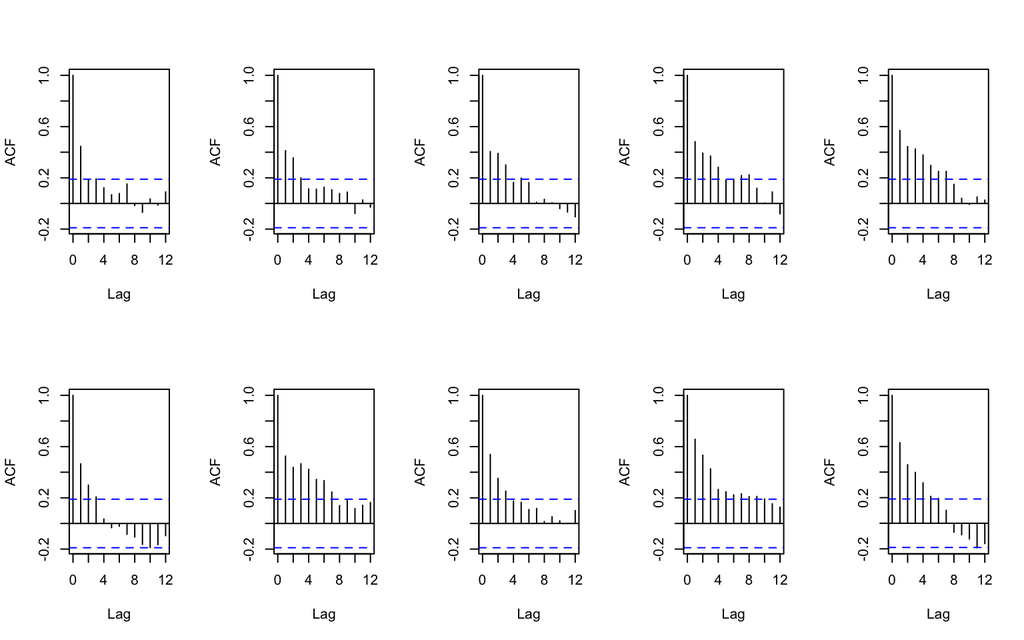

```r
set.seed(227342)
# solo 10 gráficas
sims_1 <- simulate(mod_1, nsim = 9)
terremotos_null <- data.frame(num = sims_1@response[[1]][[1]]@y,
  anio = rep(terremotos$anio, 9)) %>%
  rbind(terremotos)
codigo <- sample(1:10)
terremotos_null$tipo <- rep(codigo, each = 107)

par(mfrow=c(2, 5))
sims_x <- ddply(terremotos_null, 'tipo', function(df){
  x <- df$num
  acf(x, lag.max=12, main="")
  x
})
```

Podemos ver el desempeño de estos modelos en predicción:

```r
set.seed(72)
preds_2  <- sapply(50:106 ,function(i){
  dat.1 <- terremotos[1:i,,drop=FALSE]
  mod.1 <- depmix(num~1, data=dat.1, nstates=3,
                   family=poisson(), ntimes=i)
  fit.mod.1 <- fit(mod.1, verbose = FALSE, emcontrol=em.control(maxit=600))
  probs.1 <- fit.mod.1@posterior[i,2:4]
  estado.i <- sample(1:3, 1, prob=probs.1)
  estado.pred <- which.max(predict(fit.mod.1@transition[[estado.i]]))
  fit.mod.1@response[[estado.pred]][[1]]@parameters[1]$coefficients
})
```

[output not shown]

```r
## error medio absoluto
mean(abs(exp(preds_2) - terremotos[51:107,"num"]))
```

```
## [1] 4.4
```

Finalmente, comparamos con la predicción de tomar el valor anterior:

```r
mean(abs(terremotos[51:107, "num"] - terremotos[50:106, "num"]))
```

```
## [1] 5
```

**Ejemplo: prototipo reconocimiento de trazo de dígitos.** Los modelos de estados escondidos se usan en varias partes de procesamiento de señales. En este ejemplo, veremos un enfoque para reconocer dígitos con base en los trazos que se hacen para escribirlos, este es un enfoque distinto al usual en donde se trabaja con una matriz de pixeles. Utilizaremos los datos [pendigits](http://mlearn.ics.uci.edu/databases/pendigits/).

```r
load('./pendigits/digitos_lista.RData')
load('./pendigits/digitos.RData')
length(results.list)
```

```
## [1] 7494
```

```r
digito <- results.list[[1]]
digito
```

```
##      [,1] [,2]
## init  267  333
##       267  336
##       267  339
##       266  342
##       264  344
##       262  346
##       259  346
##       254  347
##       249  346
##       244  345
##       239  343
##       235  340
##       233  333
##       233  327
```

[output cut: 64 more lines]

```r
floor(nrow(digito)/9)
```

```
## [1] 8
```

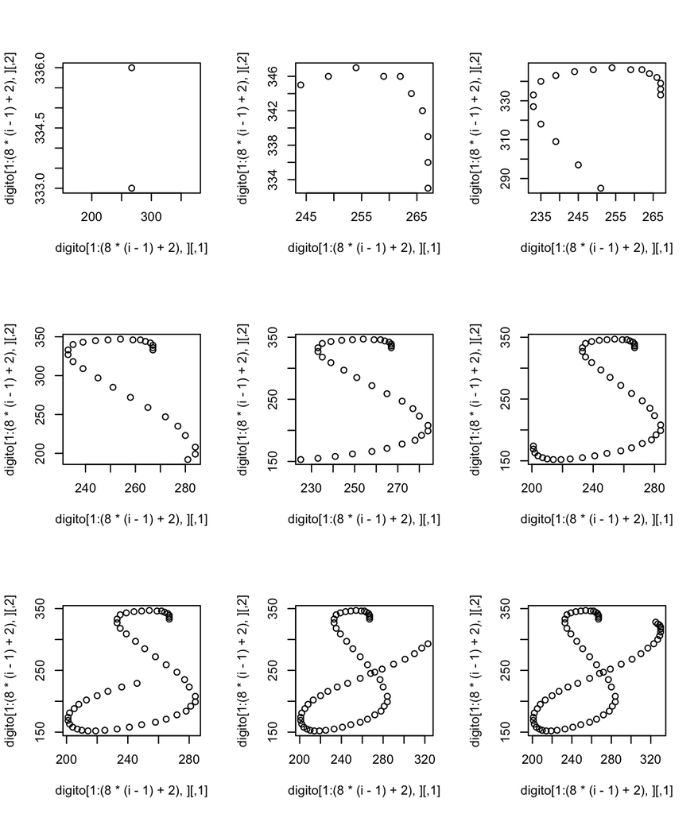

```r
par(mfrow=c(3,3))
for(i in 1:9){
  plot(digito[1:(8*(i-1)+2),])
}
```

Nos interesa construir un modelo que describa la escritura de estos dígitos. Proponemos un modelo como sigue:

- El espacio de estados ocultos tiene 16 estados distintos.
- La matriz de transición entre estados es de *izquierda a derecha*. Es decir, la serie comienza en el estado 1, y solamente transiciona de 1 a 2, de 2 a 3 y así sucesivamente. Puede permanecer un número arbitrario de tiempos en cada estado.
- Las observaciones son bivariadas: tenemos un ángulo de trazo (8 posibles direcciones), y una velocidad de trazo (que supondremos gaussiano). Supondremos estas dos variables son condicionalmente independientes dado el estado.

La idea general es:

1. Transformar los patrones de escritura a observaciones de ángulo y velocidad.
2. Ajustar un modelo distinto para cada uno de los dígitos.
3. Cuando observamos un dígito nuevo, calculamos la verosimilitud de la observación bajo los distintos modelos.
4. Clasificamos al dígito con verosimilitud más alta.

En estas notas veremos los primeros dos pasos.

La ventaja de usar HMM en este contexto es, en primer lugar, que no es necesario normalizar los dígitos a una longitud fija (aunque esto puede ayudar en la predicción), y mejor aún, que el modelo es flexible en cuanto a escalamientos de distintas partes de la escritura de los dígitos, por ejemplo, dibujar más lentamente unas partes, hacer un ocho con la parte de arriba más grande que la de abajo, etc.

Primero construimos funciones auxiliares:

```r
# convertirSerie: recibe las coordenadas y devuelve el ángulo y la velocidad
convertirSerie <- function(patron){
  d_1 <- rbind(patron[-1, ], c(NA,NA)) - patron
  d_2 <- d_1[-nrow(d_1), ]
  angulo <- acos(d_2[, 1] / (apply(d_2, 1, function(x) sqrt(sum(x ^ 2))))) *
    sign(d_2[, 2])
  velocidad <- apply(d_2, 1, function(x) sqrt(sum(x ^ 2)))
  dat_out<- data.frame(angulo = angulo[], velocidad = velocidad[])
  dat_out[!is.na(dat_out$angulo), ]
}

# trazar: recibe ángulo y velocidad y devuelve coordenadas
trazar <- function(datos){
  angulos <- datos[, 1]
  velocidad <- datos[, 2]
  longitud <- length(angulos) + 1
  puntos <- data.frame(x = rep(NA, longitud), y = rep(NA, longitud))
  puntos[1, ] <- c(0, 0)
  for(i in 2:length(angulos)){
    puntos[i,] <- puntos[i - 1, ] + velocidad[i - 1] *
      c(cos(angulos[i - 1]), sin(angulos[i - 1]))
  }
  puntos
}

con_ang <- convertirSerie(results.list[[6]])
con_ang
```

```
##    angulo velocidad
## 1   0.695       7.8
## 2   0.675       6.4
## 3   1.571       4.0
## 4   0.000       2.0
## 5  -2.521       8.6
## 6  -2.467      12.8
## 7  -2.356      17.0
## 8  -2.260      22.0
## 9  -2.196      22.2
## 10 -2.185      20.8
## 11 -2.013      21.0
## 12 -1.930      17.1
## 13 -1.642      14.0
## 14 -1.305      11.4
## 15 -0.559       9.4
## 16 -0.091      11.0
## 17  0.000      11.0
## 18  0.180      11.2
## 19  0.464       8.9
## 20  0.785       8.5
## 21  1.373       5.1
## 22  2.246       6.4
## 23  2.622       8.1
## 24  2.923       9.2
## 25  3.051      11.0
## 26 -2.863       7.3
## 27 -2.976       6.1
```

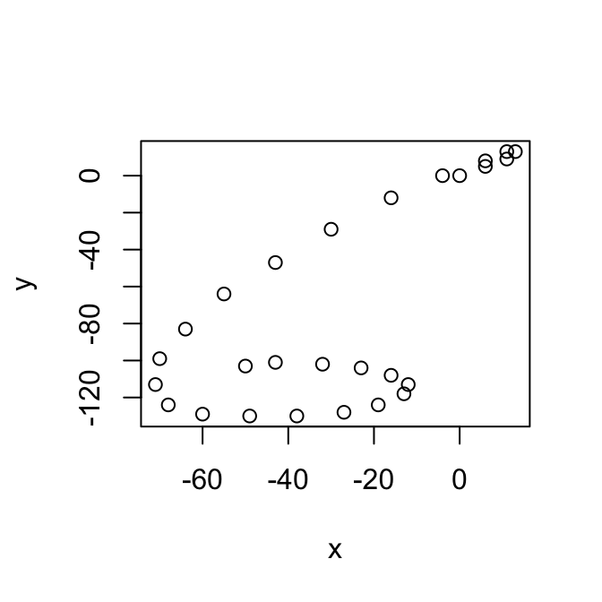

```r
plot(trazar(con_ang))
```

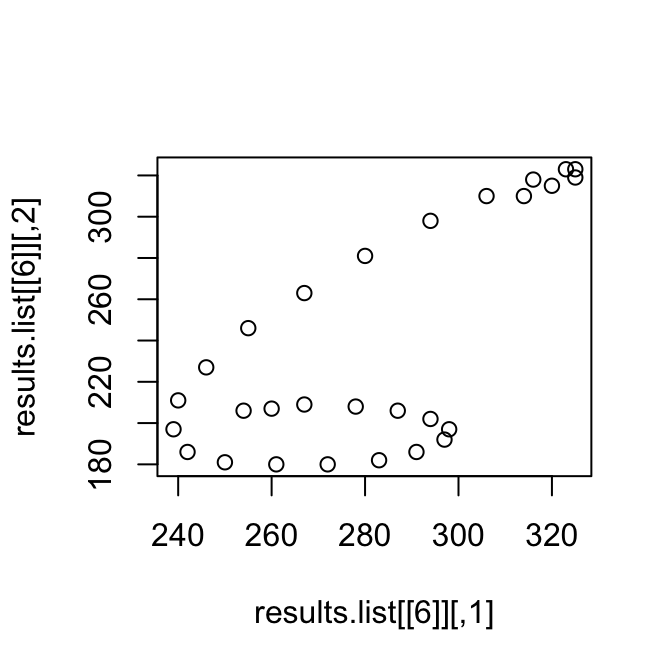

```r
plot(results.list[[6]])
```

Comenzamos seleccionando los dígitos 8, convertimos los datos a una tabla, y categorizamos los ángulos:

```r
library(Hmisc)

filtro <- sapply(digitos, function(x) x==8)
resultados <- results.list[filtro]

dat_8 <- ldply(1:700, function(i){
  conv_1 <- convertirSerie(resultados[[i]])
  data.frame(angulo = conv_1[,1], velocidad = conv_1[,2], serie=i,
    tiempo=1:nrow(conv_1))
})
head(dat_8)
```

```
##   angulo velocidad serie tiempo
## 1    1.6       3.0     1      1
## 2    1.6       3.0     1      2
## 3    1.9       3.2     1      3
## 4    2.4       2.8     1      4
## 5    2.4       2.8     1      5
## 6    0.0       3.0     1      6
```

```r
# Longitud de los dígitos
longitudes <- ddply(dat_8, 'serie', summarise, long=max(tiempo))

# Creamos 8 categorías usando cuantiles
dat_8$angulo_cat <- factor(cut2(dat_8$angulo, g = 8, levels.mean = TRUE))
levs <- as.numeric(levels(dat_8$angulo_cat))
```

Ahora construimos nuestro modelo. Una diferencia importante en relación a los ejempos anteriores es que aquí tenemos varias series de tiempo observadas (cuyas longitudes están en el argumento *ntimes* abajo):

```r
mod <- depmix(list(angulo_cat ~ 1, velocidad ~ 1), data = dat_8,
    nstates = 16,
    family =  list(multinomial("identity"), gaussian()),
    ntimes = longitudes$long)
```

El modelo está incializado de la siguiente forma

```r
summary(mod)
```

```
## Initial state probabilties model
##   pr1   pr2   pr3   pr4   pr5   pr6   pr7   pr8   pr9  pr10  pr11  pr12
## 0.062 0.062 0.062 0.062 0.062 0.062 0.062 0.062 0.062 0.062 0.062 0.062
##  pr13  pr14  pr15  pr16
## 0.062 0.062 0.062 0.062
##
##
## Transition matrix
##          toS1  toS2  toS3  toS4  toS5  toS6  toS7  toS8  toS9 toS10 toS11
## fromS1  0.062 0.062 0.062 0.062 0.062 0.062 0.062 0.062 0.062 0.062 0.062
## fromS2  0.062 0.062 0.062 0.062 0.062 0.062 0.062 0.062 0.062 0.062 0.062
## fromS3  0.062 0.062 0.062 0.062 0.062 0.062 0.062 0.062 0.062 0.062 0.062
## fromS4  0.062 0.062 0.062 0.062 0.062 0.062 0.062 0.062 0.062 0.062 0.062
## fromS5  0.062 0.062 0.062 0.062 0.062 0.062 0.062 0.062 0.062 0.062 0.062
## fromS6  0.062 0.062 0.062 0.062 0.062 0.062 0.062 0.062 0.062 0.062 0.062
## fromS7  0.062 0.062 0.062 0.062 0.062 0.062 0.062 0.062 0.062 0.062 0.062
## fromS8  0.062 0.062 0.062 0.062 0.062 0.062 0.062 0.062 0.062 0.062 0.062
## fromS9  0.062 0.062 0.062 0.062 0.062 0.062 0.062 0.062 0.062 0.062 0.062
## fromS10 0.062 0.062 0.062 0.062 0.062 0.062 0.062 0.062 0.062 0.062 0.062
## fromS11 0.062 0.062 0.062 0.062 0.062 0.062 0.062 0.062 0.062 0.062 0.062
## fromS12 0.062 0.062 0.062 0.062 0.062 0.062 0.062 0.062 0.062 0.062 0.062
## fromS13 0.062 0.062 0.062 0.062 0.062 0.062 0.062 0.062 0.062 0.062 0.062
## fromS14 0.062 0.062 0.062 0.062 0.062 0.062 0.062 0.062 0.062 0.062 0.062
## fromS15 0.062 0.062 0.062 0.062 0.062 0.062 0.062 0.062 0.062 0.062 0.062
## fromS16 0.062 0.062 0.062 0.062 0.062 0.062 0.062 0.062 0.062 0.062 0.062
##         toS12 toS13 toS14 toS15 toS16
## fromS1  0.062 0.062 0.062 0.062 0.062
## fromS2  0.062 0.062 0.062 0.062 0.062
## fromS3  0.062 0.062 0.062 0.062 0.062
## fromS4  0.062 0.062 0.062 0.062 0.062
## fromS5  0.062 0.062 0.062 0.062 0.062
## fromS6  0.062 0.062 0.062 0.062 0.062
## fromS7  0.062 0.062 0.062 0.062 0.062
## fromS8  0.062 0.062 0.062 0.062 0.062
## fromS9  0.062 0.062 0.062 0.062 0.062
## fromS10 0.062 0.062 0.062 0.062 0.062
## fromS11 0.062 0.062 0.062 0.062 0.062
## fromS12 0.062 0.062 0.062 0.062 0.062
## fromS13 0.062 0.062 0.062 0.062 0.062
## fromS14 0.062 0.062 0.062 0.062 0.062
```

[output cut: 25 more lines]

```
## St2                0      1
## St3                0      1
## St4                0      1
## St5                0      1
## St6                0      1
## St7                0      1
## St8                0      1
## St9                0      1
## St10               0      1
## St11               0      1
## St12               0      1
## St13               0      1
## St14               0      1
## St15               0      1
## St16               0      1
```

pero antes de ajustarlo, es necesario restringir los parámetros como describimos arriba (para tener un modelo de izquierda a derecha)

```r
# usamos setpars para ver el orden de los parámetros y poder escribir las
# restricciones
setpars(mod, value=1:npar(mod))
```

```
## Initial state probabilties model
##  pr1  pr2  pr3  pr4  pr5  pr6  pr7  pr8  pr9 pr10 pr11 pr12 pr13 pr14 pr15
##    1    2    3    4    5    6    7    8    9   10   11   12   13   14   15
## pr16
##   16
##
##
## Transition matrix
##         toS1 toS2 toS3 toS4 toS5 toS6 toS7 toS8 toS9 toS10 toS11 toS12
## fromS1    17   18   19   20   21   22   23   24   25    26    27    28
## fromS2    33   34   35   36   37   38   39   40   41    42    43    44
## fromS3    49   50   51   52   53   54   55   56   57    58    59    60
## fromS4    65   66   67   68   69   70   71   72   73    74    75    76
## fromS5    81   82   83   84   85   86   87   88   89    90    91    92
## fromS6    97   98   99  100  101  102  103  104  105   106   107   108
## fromS7   113  114  115  116  117  118  119  120  121   122   123   124
## fromS8   129  130  131  132  133  134  135  136  137   138   139   140
## fromS9   145  146  147  148  149  150  151  152  153   154   155   156
## fromS10  161  162  163  164  165  166  167  168  169   170   171   172
## fromS11  177  178  179  180  181  182  183  184  185   186   187   188
## fromS12  193  194  195  196  197  198  199  200  201   202   203   204
## fromS13  209  210  211  212  213  214  215  216  217   218   219   220
## fromS14  225  226  227  228  229  230  231  232  233   234   235   236
## fromS15  241  242  243  244  245  246  247  248  249   250   251   252
## fromS16  257  258  259  260  261  262  263  264  265   266   267   268
##         toS13 toS14 toS15 toS16
## fromS1     29    30    31    32
## fromS2     45    46    47    48
## fromS3     61    62    63    64
## fromS4     77    78    79    80
## fromS5     93    94    95    96
## fromS6    109   110   111   112
## fromS7    125   126   127   128
## fromS8    141   142   143   144
## fromS9    157   158   159   160
## fromS10   173   174   175   176
## fromS11   189   190   191   192
## fromS12   205   206   207   208
## fromS13   221   222   223   224
## fromS14   237   238   239   240
```

[output cut: 25 more lines]

```
## St2              291    292
## St3              301    302
## St4              311    312
## St5              321    322
## St6              331    332
## St7              341    342
## St8              351    352
## St9              361    362
## St10             371    372
## St11             381    382
## St12             391    392
## St13             401    402
## St14             411    412
## St15             421    422
## St16             431    432
```

```r
pars <- c(unlist(getpars(mod)))
# Restringimos a solo poder ir del estado uno al dos, dos al tres, ...
# esto se hace modificando la inical de la matriz de transición
pars[17:272] <- 0
pars[sapply(1:16, function(i){0+17*i})] <- 1/2
pars[sapply(1:15, function(i){1+17*i})] <- 1/2
pars[255:256] <- 0.5
pars[272] <- 1
# restringimos estado inicial al 1
pars[2:16] <- 0
pars[1] <- 1
mod <- setpars(mod, pars)
summary(mod)
```

```
## Initial state probabilties model
##  pr1  pr2  pr3  pr4  pr5  pr6  pr7  pr8  pr9 pr10 pr11 pr12 pr13 pr14 pr15
##    1    0    0    0    0    0    0    0    0    0    0    0    0    0    0
## pr16
##    0
##
##
## Transition matrix
##         toS1 toS2 toS3 toS4 toS5 toS6 toS7 toS8 toS9 toS10 toS11 toS12
## fromS1   0.5  0.5  0.0  0.0  0.0  0.0  0.0  0.0  0.0   0.0   0.0   0.0
## fromS2   0.0  0.5  0.5  0.0  0.0  0.0  0.0  0.0  0.0   0.0   0.0   0.0
## fromS3   0.0  0.0  0.5  0.5  0.0  0.0  0.0  0.0  0.0   0.0   0.0   0.0
## fromS4   0.0  0.0  0.0  0.5  0.5  0.0  0.0  0.0  0.0   0.0   0.0   0.0
## fromS5   0.0  0.0  0.0  0.0  0.5  0.5  0.0  0.0  0.0   0.0   0.0   0.0
## fromS6   0.0  0.0  0.0  0.0  0.0  0.5  0.5  0.0  0.0   0.0   0.0   0.0
## fromS7   0.0  0.0  0.0  0.0  0.0  0.0  0.5  0.5  0.0   0.0   0.0   0.0
## fromS8   0.0  0.0  0.0  0.0  0.0  0.0  0.0  0.5  0.5   0.0   0.0   0.0
## fromS9   0.0  0.0  0.0  0.0  0.0  0.0  0.0  0.0  0.5   0.5   0.0   0.0
## fromS10  0.0  0.0  0.0  0.0  0.0  0.0  0.0  0.0  0.0   0.5   0.5   0.0
## fromS11  0.0  0.0  0.0  0.0  0.0  0.0  0.0  0.0  0.0   0.0   0.5   0.5
## fromS12  0.0  0.0  0.0  0.0  0.0  0.0  0.0  0.0  0.0   0.0   0.0   0.5
## fromS13  0.0  0.0  0.0  0.0  0.0  0.0  0.0  0.0  0.0   0.0   0.0   0.0
## fromS14  0.0  0.0  0.0  0.0  0.0  0.0  0.0  0.0  0.0   0.0   0.0   0.0
## fromS15  0.0  0.0  0.0  0.0  0.0  0.0  0.0  0.0  0.0   0.0   0.0   0.0
## fromS16  0.0  0.0  0.0  0.0  0.0  0.0  0.0  0.0  0.0   0.0   0.0   0.0
##         toS13 toS14 toS15 toS16
## fromS1    0.0   0.0   0.0   0.0
## fromS2    0.0   0.0   0.0   0.0
## fromS3    0.0   0.0   0.0   0.0
## fromS4    0.0   0.0   0.0   0.0
## fromS5    0.0   0.0   0.0   0.0
## fromS6    0.0   0.0   0.0   0.0
## fromS7    0.0   0.0   0.0   0.0
## fromS8    0.0   0.0   0.0   0.0
## fromS9    0.0   0.0   0.0   0.0
## fromS10   0.0   0.0   0.0   0.0
## fromS11   0.0   0.0   0.0   0.0
## fromS12   0.5   0.0   0.0   0.0
## fromS13   0.5   0.5   0.0   0.0
## fromS14   0.0   0.5   0.5   0.0
```

[output cut: 25 more lines]

```
## St2                0      1
## St3                0      1
## St4                0      1
## St5                0      1
## St6                0      1
## St7                0      1
## St8                0      1
## St9                0      1
## St10               0      1
## St11               0      1
## St12               0      1
## St13               0      1
## St14               0      1
## St15               0      1
## St16               0      1
```

Ahora ajustamos usando EM:

```r
set.seed(280572)
fm <- fit(mod,  emcontrol=em.control(maxit=100))
```

```
## iteration 0 logLik: -147614
## iteration 5 logLik: -125759
## iteration 10 logLik: -124984
## iteration 15 logLik: -124584
## iteration 20 logLik: -124487
## iteration 25 logLik: -124415
## iteration 30 logLik: -123993
## iteration 35 logLik: -123867
## iteration 40 logLik: -123859
## iteration 45 logLik: -123858
## iteration 50 logLik: -123850
## iteration 55 logLik: -123828
## iteration 60 logLik: -123821
## iteration 65 logLik: -123821
## iteration 70 logLik: -123821
## iteration 75 logLik: -123821
## iteration 80 logLik: -123821
## converged at iteration 82 with logLik: -123821
```

```r
summary(fm)
```

```
## Initial state probabilties model
##  pr1  pr2  pr3  pr4  pr5  pr6  pr7  pr8  pr9 pr10 pr11 pr12 pr13 pr14 pr15
##    1    0    0    0    0    0    0    0    0    0    0    0    0    0    0
## pr16
##    0
##
##
## Transition matrix
##         toS1 toS2 toS3 toS4 toS5 toS6 toS7 toS8 toS9 toS10 toS11 toS12
## fromS1  0.78 0.22 0.00 0.00 0.00 0.00 0.00 0.00 0.00  0.00  0.00  0.00
## fromS2  0.00 0.55 0.45 0.00 0.00 0.00 0.00 0.00 0.00  0.00  0.00  0.00
## fromS3  0.00 0.00 0.64 0.36 0.00 0.00 0.00 0.00 0.00  0.00  0.00  0.00
## fromS4  0.00 0.00 0.00 0.57 0.43 0.00 0.00 0.00 0.00  0.00  0.00  0.00
## fromS5  0.00 0.00 0.00 0.00 0.46 0.54 0.00 0.00 0.00  0.00  0.00  0.00
## fromS6  0.00 0.00 0.00 0.00 0.00 0.68 0.32 0.00 0.00  0.00  0.00  0.00
## fromS7  0.00 0.00 0.00 0.00 0.00 0.00 0.63 0.37 0.00  0.00  0.00  0.00
## fromS8  0.00 0.00 0.00 0.00 0.00 0.00 0.00 0.41 0.59  0.00  0.00  0.00
## fromS9  0.00 0.00 0.00 0.00 0.00 0.00 0.00 0.00 0.55  0.45  0.00  0.00
## fromS10 0.00 0.00 0.00 0.00 0.00 0.00 0.00 0.00 0.00  0.58  0.42  0.00
## fromS11 0.00 0.00 0.00 0.00 0.00 0.00 0.00 0.00 0.00  0.00  0.58  0.42
## fromS12 0.00 0.00 0.00 0.00 0.00 0.00 0.00 0.00 0.00  0.00  0.00  0.58
## fromS13 0.00 0.00 0.00 0.00 0.00 0.00 0.00 0.00 0.00  0.00  0.00  0.00
## fromS14 0.00 0.00 0.00 0.00 0.00 0.00 0.00 0.00 0.00  0.00  0.00  0.00
## fromS15 0.00 0.00 0.00 0.00 0.00 0.00 0.00 0.00 0.00  0.00  0.00  0.00
## fromS16 0.00 0.00 0.00 0.00 0.00 0.00 0.00 0.00 0.00  0.00  0.00  0.00
##         toS13 toS14 toS15 toS16
## fromS1   0.00  0.00  0.00   0.0
## fromS2   0.00  0.00  0.00   0.0
## fromS3   0.00  0.00  0.00   0.0
## fromS4   0.00  0.00  0.00   0.0
## fromS5   0.00  0.00  0.00   0.0
## fromS6   0.00  0.00  0.00   0.0
## fromS7   0.00  0.00  0.00   0.0
## fromS8   0.00  0.00  0.00   0.0
## fromS9   0.00  0.00  0.00   0.0
## fromS10  0.00  0.00  0.00   0.0
## fromS11  0.00  0.00  0.00   0.0
## fromS12  0.42  0.00  0.00   0.0
## fromS13  0.68  0.32  0.00   0.0
## fromS14  0.00  0.84  0.16   0.0
```

[output cut: 25 more lines]

```
## St2              7.3    3.2
## St3             10.9    4.9
## St4             10.1    3.9
## St5             12.8    4.4
## St6             16.6    4.7
## St7             18.1    8.9
## St8             12.2    2.9
## St9              9.6    2.7
## St10            10.3    3.5
## St11            10.4    3.5
## St12            10.6    4.1
## St13            14.8    5.5
## St14            15.4    5.4
## St15             7.9    2.9
## St16            10.4    4.2
```

Y podemos simular algunas trayectorias:

```r
set.seed(2805)
fm_1 <- fm
class(fm_1) <- 'depmix'
sim_1 <- simulate(fm_1)
resp_1 <- sim_1@response
estados <- sim_1@states

angulosSim <- lapply(resp_1[estados], function(x){
  params <- x[[1]]@parameters$coefficients
  c(sample(levs, 1, prob=params ), rnorm(1, x[[2]]@parameters[1][[1]], sd=x[[2]]@parameters[2]$sd))
   # rnorm(1, params[[1]], sd=params$sd )}
}
)
dat_x <- data.frame(Reduce(rbind, angulosSim))
names(dat_x) <- c('angulo','velocidad')
# estados
head(dat_x, 6)
```

```
##   angulo velocidad
## 1  -0.48       3.7
## 2   2.77       7.5
## 3  -0.48       9.4
## 4  -0.48      12.4
## 5   2.77       4.4
## 6  -2.78       9.1
```

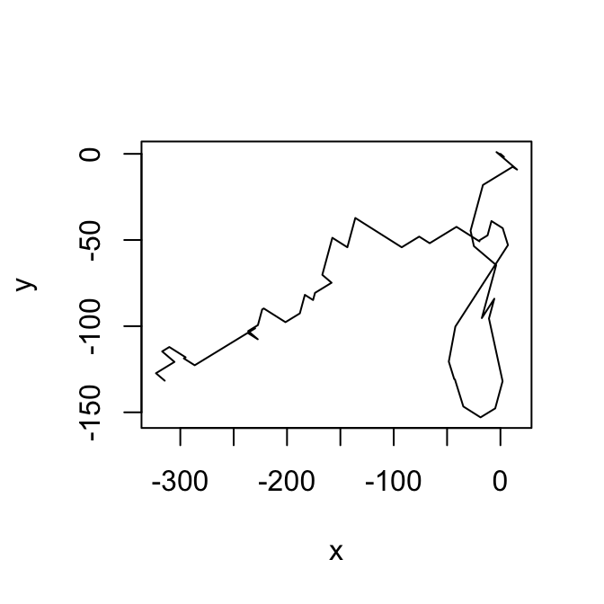

```r
plot(trazar(dat_x[1:78,]), type='l')
```

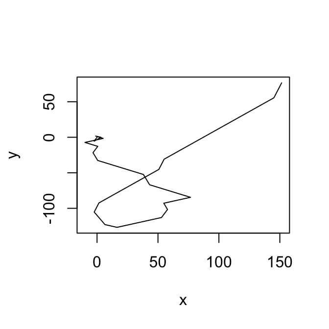

```r
plot(trazar(dat_x[79:(38+78),]), type='l')
```

La ruta de máxima probabilidad (estados) se puede ver en el objeto *posterior*. Esta secuencia indica los estados más probables en el sentido de máxima probabilidad posterior (MAP).

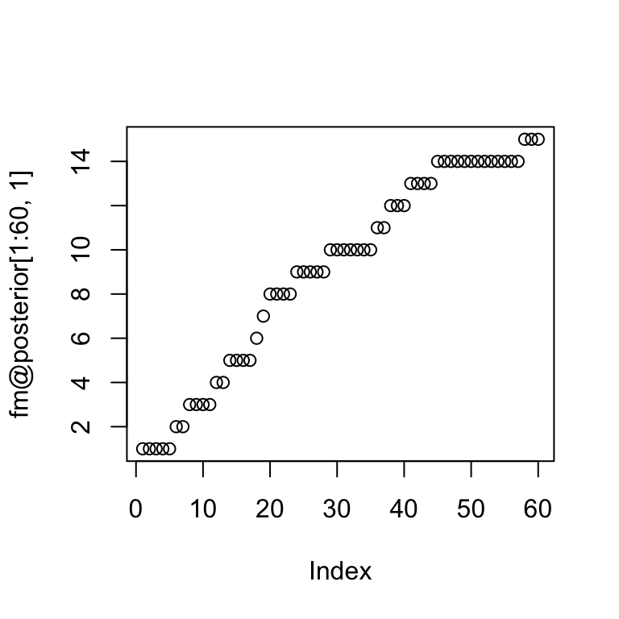

```r
plot(fm@posterior[1:60,1])
```

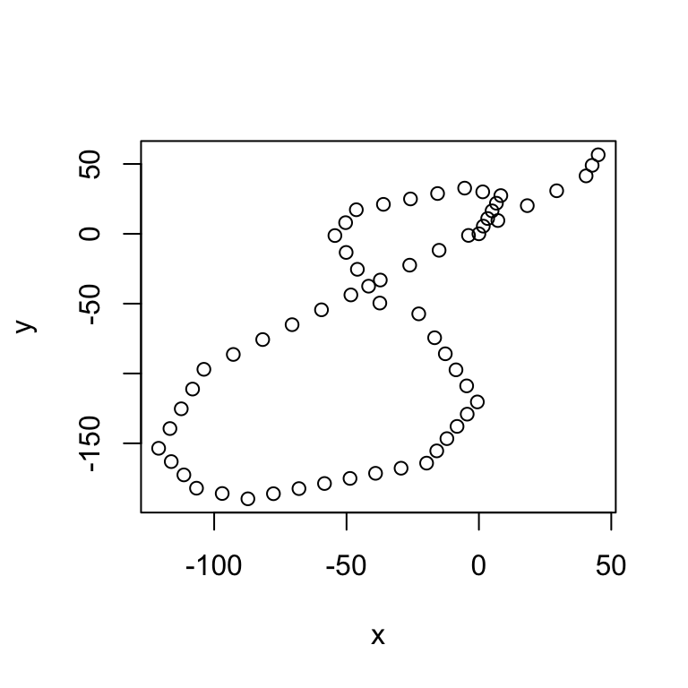

```r
respuesta <- fm@response[fm@posterior[1:60,1]]
post <- ldply(respuesta, function(comp){
  angulo.probs <- comp[[1]]@parameters$coefficients
  velocidad <- comp[[2]]@parameters$coefficients
  c(levs[which.max(angulo.probs)], velocidad)
})
names(post) <- c('angulo.cut','velocidad')
plot(trazar(post))
```

En el caso de arriba, se inició en el estado 1 (por construcción), permaneció ahí por 5 tiempos, pasó al estado 2,…

Veamos el caso del dígito 3:

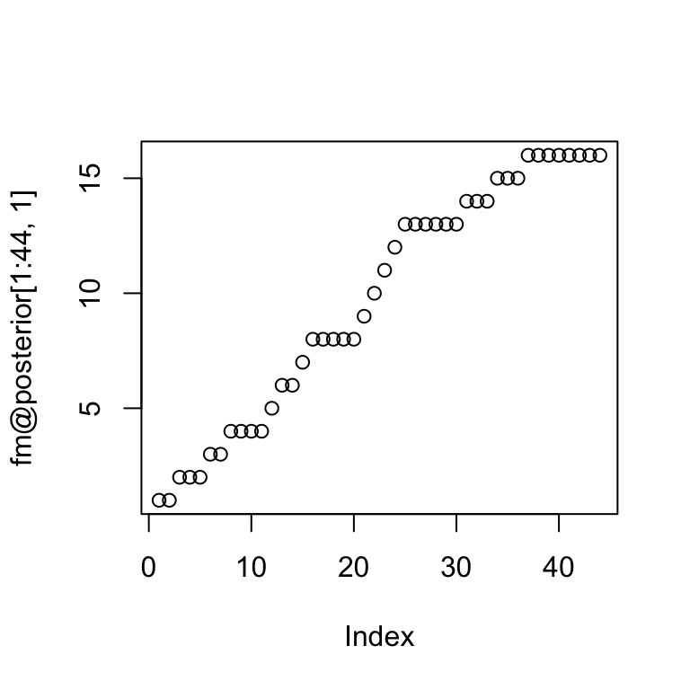

```r
load('./pendigits/modelo_digitos_3.RData')

filtro <- sapply(digitos, function(x) x==3)

resultados <- results.list[filtro]

dat.6 <- ldply(1:500, function(i){
  conv.1 <- convertirSerie(resultados[[i]])
  data.frame(angulo=conv.1[,1], velocidad=conv.1[,2], serie=i, tiempo=1:nrow(conv.1))
})

longitudes <- ddply(dat.6, 'serie', summarise, long=max(tiempo))

dat.6$angulo.cut <- factor(cut2(dat.6$angulo, g=8, levels.mean=TRUE))
levs <- as.numeric(levels(dat.6$angulo.cut))

plot(fm@posterior[1:44,1])
```

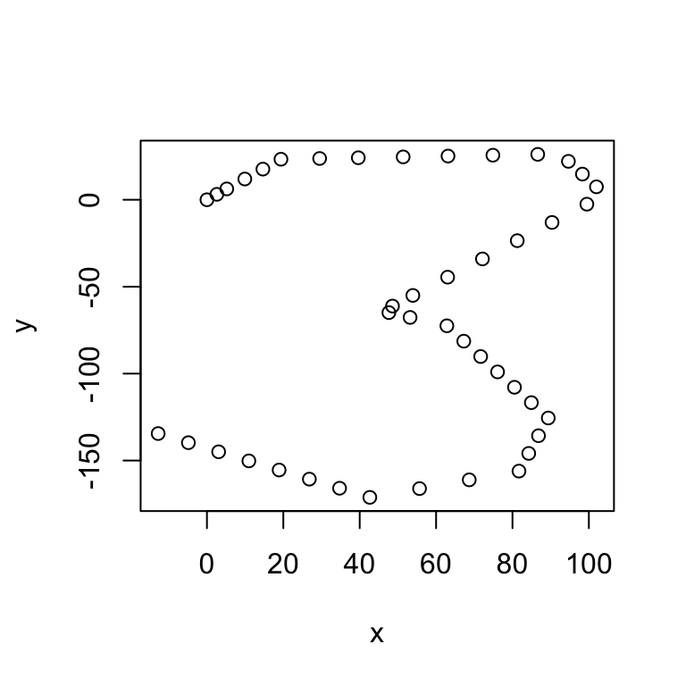

```r
respuesta <- fm@response[fm@posterior[1:44,1]]
post <- ldply(respuesta, function(comp){
  angulo.probs <- comp[[1]]@parameters$coefficients
  velocidad <- comp[[2]]@parameters$coefficients
  c(levs[which.max(angulo.probs)], velocidad)
})
names(post) <- c('angulo.cut','velocidad')
plot(trazar(post))
```

En HMM, la variable $x_{n+1}$ es independiente de:

1. $x_1,...,x_{n}$
2. $x_1,...,x_{n-1}$
3. $x_{n-1}$
4. Ninguna de las anteriores.

Sea $A$ la matriz de transición en un HMM. Un modelo de mezclas para datos iid corresponde a un caso especial de HMM donde:

1. $A_{jk}$ toman el mismo valor para toda $j$.
2. $A_{jk}$ toman el mismo valor para toda $j$ y para toda $k$.
3. $A_{jk}$ toman el mismo valor para toda $k$.
4. Ninguna de las anteriores.

### Algoritmo EM para modelos markovianos de estados ocultos

Ahora veremos cómo se construye el paso E y M del algoritmo esperanza- maximización para HMM.

Similar al caso de varaibles latentes, comenzamos escribiendo la verosimilitud con datos completos. La serie de datos observados la denotamos como $X=X_1,\ldots, X_T$ y la de datos latentes $S=S_1,\ldots, S_T.$

Supongamos que tenemos una observación $x=x_1,\ldots, x_T$ con $s=s_1,\ldots, s_T$. Si suponemos que $P(S_1=s_1)=1$ la verosimilitud (usando nuestro modelo HMM) es

$P(x,S=s)=P(x_1|S_1=s_1)P(S_2=s_2|S_1=s_1)P(x_2|S_2=s_2)\cdots P(S_{T}=s_T|S_{T-1}=s_{t-1})P(x_T|S_T=s_T).$

Si denotamos $p_{ij}=P(S_t=j|S_{t-1}=i)$ y $p_j=P(x_t|S_t=j)$. Tomando logaritmo y reacomodando:

$\log P(x,S=s) =\sum_{t=2}^t \log p_{s_{t-1}, s_{t}} + \sum_{t=1}^T \log p_{s_t}(x_t).$

Nos conviene reescribir esta ecuación de otra manera. Introducimos entonces las variables indicadoras $u_j(t)$, tales que $u_j(t)=1$ si y sólo si $s_t=j$, y $v_{ij}(t)$, tales que $v_{ij}(t)=1$ si y sólo si $s_{t-1}=i, s_{t}=j$. Entonces podemos reescribr

$\log P(x,S=s) = \sum_{i=1}^M\sum_{j=1}^M \left( \sum_{t=2}^T v_{ij} (t) \right) \log p_{ij} + \sum_{i=1}^M \sum_{t=1}^T u_i(t)\log p_i(x_t).$

A partir de esta ecuación es fácil ver la forma del algoritmo.

1. Paso **E**: Necesitamos calcular el valor esperado condicional (dados los datos observados $X$) de la expresión de arriba. Basta entonces calcular $\delta_j (t)=E(u_j(t)|X)=P(S_t=j|X)$ y $\gamma_{ij}(t) =E(v_{ij}(t)|X)=P(S_{t-1}=i, S_{t}=j|X).$

Una vez que calculamos estas cantidades (usando el algoritmo hacia adelante-hacia atrás, o de Baum-Welch, como veremos más adelante), procedemos al paso M.

2. Paso **M**: Buscamos maximizar $\sum_{i=1}^M\sum_{j=1}^M \left( \sum_{t=2}^T \hat{\gamma}_{ij} (t) \right) \log p_{ij} + \sum_{i=1}^M \sum_{t=1}^T \hat{\delta}_i(t)\log p_i(x_t).$
- Notemos que la optimización de los parámetros de $p_i$ se puede separar de la correspondiente a $\hat{p}_{ij}$. Más aun, la optimización de $\hat{p}_{ij}$ se puede separar para cada $i$.
- Es fácil ver que $\hat{p}_{ij}=\frac{\hat{\gamma}_{ij}}{\sum_l \hat{\gamma}_{il}}$ donde $\hat{\gamma}_{ij}=\sum_{t=2}^T \hat{\gamma}_{ij} (t),$ que son conteos ponderados por las probabilidades que resultan del paso E.
- Para el segundo término, tenemos que usar la forma particular de las densidades condicionales $p_j(x)$. Si suponemos $p_i$ densidad Normal $\hat{\mu_i}$ y $\hat{\Sigma_i}$ resultan: $\hat{\mu_i}=\frac{\sum_{t=1}^T \hat{\delta_i}(t) x_t}{\sum_{t=1}^T \hat{\delta_i}(t)}$ $\hat{\Sigma_i}=\frac{\sum_{t=1}^T \hat{\delta_i}(t) (x_t-\hat{\mu}_i)(x_t-\hat{\mu}_i)^T}{\sum_{t=1}^T \hat{\delta}(t)}$ es el mismo caso que en mezcla de normales. Como ejercicio, calcula para el modelo Poisson.

## Algoritmo hacia adelante-hacia atrás (forward-backward)

Utilizamos el algoritmo *forward-backward* para calcular $\hat{\gamma}_{ij}$ y $\hat{\delta}_j$. Recordemos que

$\begin{aligned} \hat{\delta}_{j}&=P(S_{t}=j|x)=\frac{P(x, S_t=j)}{P(x)}\\ \hat{\gamma}_{ij}&=P(S_{t-1}=i,S_t=j|x)=\frac{P(x,S_{t-1}=i,S_t=j)}{P(x)} \end{aligned}$

El cálculo de cada una de las probabilidades de arriba es computacionalmente intensivo, por ejemplo para calcular $P(x)$:

$P(x)=\sum_{\mathcal{S}} p_{s_1}(x_1)p_{s_1,s_2}p_{s_2}(x_2)\cdots p_{s_{T-1},s_T}p_{s_T}(x_T)$

donde $\mathcal{S}$ son las combinaciones de posibles estados ($M^T$ posibilidades) por tanto esta aproximación no es factible. Es por esto que surge la necesidad de un algoritmo más eficiente.

El algoritmo hacia adelante-hacia atrás usa el principio de programación dinámica(recursión inteligente) para calcular $\hat{\gamma}_{ij}$ y $\hat{\delta}_j$ en tiempo lineal ($M^2T$), consta de dos pasos y explota las independencias condicionales del modelo.

#### Probabilidad hacia adelante

Definimos la probabilidad hacia adelante $\alpha_i(t)$ como la probabilidad conjunta de observar las primeras $t$ observaciones $x^j$ ($j=1,...,t$) y siendo $i$ el estado al tiempo $t$:

$\alpha_i(t)=P(X_1=x_1,...,X_T=x_t,S_t=i)$

La probabilidad se puede evaluar de manera recursiva siguiendo la fórmula:

1. $\alpha_i(1) = \pi_k p_i(x_1)$ para $i=1,...,M$
2. $\alpha_i(t) = p_i(x_t)\sum_{j=1}^M \alpha_j(t-1)p_{j,i}$ para $t=2,...,T$ e $i=1,...,M$.

**Prueba:**

La idea clave es usar $(S_t,X_t) \perp (X_1,...,X_{t-1})|S_{t-1}$ $\begin{aligned} \alpha_i(t)&=P(x_1,...,x_t,S_t=i)\\ &=\sum_{j=1}^M P(x_1,...,x_t,S_t=i, S_{t-1}=j)\\ &=\sum_{j=1}^M P(x_1,...,x_{t-1},S_{t-1}=j)P(x_t|S_t=i)P(S_t=1|S_{t-1}=j)\\ &=\sum_{j=1}^M \alpha_j(t-1)p_i(x_t)p_{j,i}\\ \end{aligned}$

#### Probabilidad hacia atrás

Definimos la probabilidad hacia atrás $\beta_i(t)$ como la probabilidad condicional de las observaciones posteriores al tiempo $t$ ($x_{t+1},...,x_T$) dado que el estado al tiempo $t$ es $i$.

$\beta_i(t)=P(x_{t+1},...,x_T|S_t=i)$ para $t=1,...T-1$.

La recursión de la probabilidad hacia atrás se evalúa como:

1. $\beta_i(T)=1$, para $i=1,...,M$.
2. $\beta_i(t)=\sum_{i=1}^M p_{i,j}p_j(x_{t+1})\beta_i(t+1)$ para $t = 1,...,T-1$.

**Prueba:**

La idea clave es usar $X_{t+1} \perp (X_{t+2},...,X_T)|S_{t+1}$

$\begin{aligned} \beta_i(t)&=P(x_{t+1},...,x_T|S_t=i) \\ &=\sum_{j=1}^M P(x_{t+1},...,x_T,S_{t+1}=j |S_t=i)\\ &=\sum_{j=1}^M P(S_{t+1}=j|S_t=i) P(x_{t+1},...,x_T|S_{t+1}=j)\\ &=\sum_{j=1}^M p_{i,j}P(x_{t+1},...,x_T|S_{t+1}=j)\\ &=\sum_{j=1}^M p_{i,j}P(x_{t+1}|S_{t+1}=j)P(x_{t+2},...,x_T|s_{t+1}=j)\\ &=\sum_{j=1}^M p_{i,j}p_j(x_{t+1})\beta_j(t+1) \end{aligned}$

#### Escribimos $\delta$ y $\gamma$

Ahora vemos como escrbir **$\delta_j$** y $\gamma_{i,j}$ usando las probabilidades hacia adelante y hacia atrás:

$\begin{aligned} \hat{\delta}_{j}(t)&=P(S_{t}=j|x)\\ &=\frac{P(x,S_{t}=j)}{P(x)}\\ &=\frac{\alpha_j(t)\beta_j(t)}{\sum_{i=1}^M \alpha_i(T)} \end{aligned}$

**Prueba:** $\begin{aligned} P(x_1,...,x_T,S_t=j)&=P(x_1,...,x_t,S_t=j)P(x_{t+1},...,x_T|S_t=j)\\ &=\alpha_j(t)\beta_j(t) \end{aligned}$

Para el denominador notemos que:

$\begin{aligned} P(x) &= \sum_i^M P(x,S_{t}=i)\\ &= \sum_{i=1}^M \alpha_i(t)\beta_i(t) \end{aligned}$ esto se cumple para cualquier $t$, así que si tomamos $t=T$:

$P(x) = \sum_{i=1}^M \alpha_i(T)$

En el caso de **$\gamma_{i,j}$** tenemos:

$\begin{aligned} \hat{\gamma}_{ij}&=P(S_{t-1}=i,S_t=j|x)\\ &=\frac{P(x,S_{t-1}=i,S_t=j)}{P(x)}\\ &=\frac{\alpha_i(t-1)\beta_j(t)p_{i,j}p_j(x_{t})}{P(x)} \end{aligned}$

**Prueba:** $\begin{aligned} P(x_1,...,x_T,S_{t-1}=i,S_t=j)&=P(x_1,...,x_{t-1},S_{t-1}=i)P(x_{t+1},...,X_T|S_t=j)P(S_t=j|S_{t-1}=i)P(x_t|S_t=j)\\ &=\alpha_i(t-1)\beta_j(t)p_{i,j}p_j(x_{t}) \end{aligned}$

### Resumen de algoritmo de estimación

Entonces, el algoritmo de estimación itera de la siguiente manera:

1. Comenzamos con valores inciales $\hat{\delta}_j$ y $\hat{\gamma}_{ij}$.
2. Actualizamos los parámetros $\hat{p}_{ij}=\frac{\hat{\gamma}_{ij}}{\sum_l \hat{\gamma}_{il}}$ y los correspondientes a las densidades $p_j(x)$.
3. Utilizando el conjunto de parámetros actuales ($\hat{p}_{ij}$ y los correspondientes a $p_j(x)$) calculamos $\hat{\delta}_j$ y $\hat{\gamma}_{ij}$ a través del algoritmo hacia adelante-hacia atrás.
4. Iteramos entre 2 y 3.

## Algoritmo de Viterbi

En muchas de las aplicaciones de HMM nos interesa hacer inferencia de la secuencia de estados $\{S_1,...,S_T\}$, en este caso el criterio de optimización es:

$MAP(S|x)=argmax_s P(S|x) = argmax_s P(S,x)$

Aqui estamos buscando el camino más probable. Si consideramos un algoritmo de fuerza bruta, esto es, realizamos búsqueda exahustiva sobre todas las posibles secuencias tendríamos que considerar $M^T$ casos. Es por ello que nuevamente recurrimos a un algoritmo de programación dinámica.